# La Courbe Environnementale de Kuznets pour le CO₂

Une évaluation empirique par approches transversale et temporelle

A.Guilmain

I.Balde

A.Sylla

D.Adjenia

2026-01-23

# Introduction

## 🎯 La question au cœur du débat climat

### Problématique

« La croissance économique finit-elle par réduire la pollution ? »

**L’hypothèse EKC (Kuznets, 1991)**

$$\text{Pollution} = f(\text{Revenu})$$

Relation en **U inversé** :

- Phase 1 : Industrialisation → ↗️ pollution
- Phase 2 : Services + tech → ↘️ pollution

**Point de retournement** (*turning point*) : $\frac{\partial \mathrm{CO}_2}{\partial \text{PIB}} = 0$

**Notre approche originale**

✅ **Double validation empirique**

| Dimension | Échantillon | Objectif |
| --- | --- | --- |
| 📸 Espace | 159 pays (2020) | Forme |
| 🎬 Temps | USA (1990-2020) | Dynamique |

✅ **Double objectif**

- 🔍 **Estimer** la relation
- 🎯 **Prédire** le futur

## 📐 Spécification économétrique

- Modèle théorique
- Justification log-log
- Estimateurs

**Spécification log-log polynomiale**

$$\ln(\mathrm{CO}_2) = \beta_0 + \beta_1 \ln(\text{PIB}) + \beta_2 [\ln(\text{PIB})]^2 + \beta_3 [\ln(\text{PIB})]^3 + \varepsilon$$

**Interprétation des coefficients**

| Signe de $\beta_2$ | Signe de $\beta_3$ | Forme | Interprétation |
| --- | --- | --- | --- |
| $\beta_2 < 0$ | $\beta_3 = 0$ | **U inversé** | EKC classique ✅ |
| $\beta_2 < 0$ | $\beta_3 > 0$ | **N** | Rebond ! ⚠️ |
| $\beta_2 < 0$ | $\beta_3 < 0$ | **U inversé accéléré** | Déclin rapide |

**Pourquoi la transformation logarithmique ?**

**Approche transversale (N=159)**

- OLS avec erreurs-types **HC3** (robustes, N < 250)

**Approche temporelle (T=30)**

- **ARDL(1,1)** avec Newey-West (3 lags)

$$\ln(\mathrm{CO}_2)_t = \rho \ln(\mathrm{CO}_2)_{t-1} + \beta_0 \ln(\text{PIB})_t + \beta_1 \ln(\text{PIB})_{t-1} + \varepsilon_t$$

## ⚖️ Stratégie : Estimer vs Prédire

### 🔍 Estimation

**Question** : Quelle relation entre X et Y ?

**Critères**

- Significativité ($p < 0.05$)
- $R^2$ ajusté
- Tests F emboîtés

**Risque** : Biais de spécification

### 🎯 Prédiction

**Question** : Le modèle généralise-t-il ?

**Critères**

- RMSE hors-échantillon
- Comparaison benchmarks
- Validation croisée (CV)

**Risque** : Surapprentissage

**Principe de parcimonie**

Un modèle **statistiquement significatif** mais **prédictivement faible** sera rejeté.

→ Performance hors-échantillon = **arbitre final**.

# Approche Transversale

## 📸 Partie I : Validation spatiale

**159 pays (2020)** | Quelle forme prend l’EKC dans l’espace ?

## 🌍 Données et contexte empirique

- Vue d’ensemble 2020
- Trajectoires 1990-2020
- Données mobilisées

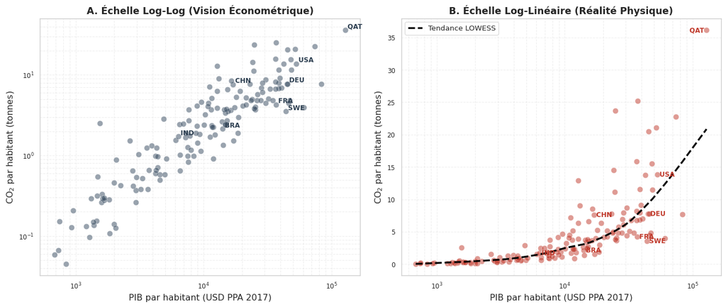

**Panel A : Justification log-log**

Relation quasi-**linéaire** en échelle log  
→ Interprétation en **élasticités**

**Panel B : Hétérogénéité**

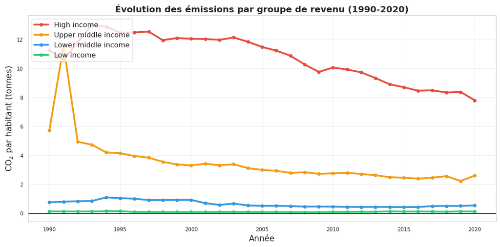

→ L’EKC ne décrit **pas** une loi universelle

**Source**

- Our World in Data (2020)
- Global Carbon Project
- Banque Mondiale

**Échantillon**

- **159 pays** (>95% PIB mondial)
- Période : **1990-2020** (30 ans)
- ~4770 observations

**Variables clés**

| Variable | Unité | Transformation |
| --- | --- | --- |
| $\mathrm{CO}_2/\text{cap}$ | tonnes/an | $\ln(\mathrm{CO}_2)$ |
| PIB/hab | $ PPA 2017 | $\ln(\text{PIB})$ centré |

**Exclusions** : 12 micro-États et paradis fiscaux  
(Liechtenstein, Monaco, Luxembourg, Singapour…)

**Justification log** : Test Box-Cox → λ = 0.15 ≈ 0

## 📈 Résultat n°1 : Le modèle quadratique suffit

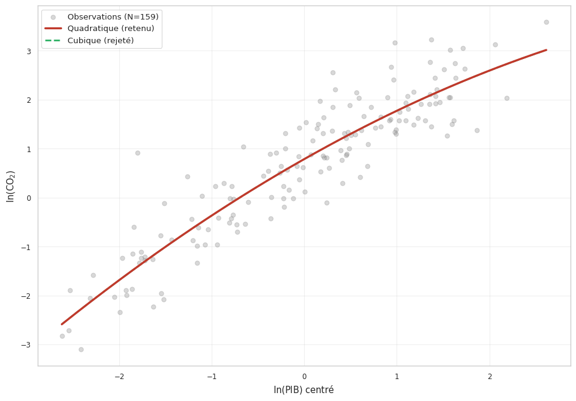

**Résultats d’estimation**

| Coefficient | Quadratique | Cubique |
| --- | --- | --- |
| $\beta_1$ | 1.070*** | 1.070*** |
| $\beta_2$ | **-0.083*** | -0.083** |
| $\beta_3$ | — | -0.0002 |
|  |  | (p=0.995) |

**Performance prédictive (CV k=5)**

| Modèle | RMSE |
| --- | --- |
| **Quadratique** | **0.568** ✅ |
| Cubique | 0.580 ❌ |

**Verdict**

✅ EKC classique validée ($\beta_2 < 0$)

❌ Courbe en N rejetée ($\beta_3 \approx 0$)

## 🔍 L’hétérogénéité masquée : Trois clubs de pays

**🔴 Sur-carbonés**

**Au-dessus de l’EKC**

- 🇶🇦 Qatar : 35 t
- 🇰🇼 Koweït : 25 t
- 🇦🇺 Australie : 17 t

*Rente fossile*

**🟡 Sur la courbe**

**Trajectoire moyenne**

- 🇺🇸 USA : 14 t
- 🇩🇪 Allemagne : 8 t
- 🇯🇵 Japon : 9 t

*Transition en cours*

**🟢 Décarbonés**

**Sous l’EKC**

- 🇸🇪 Suède : 4 t
- 🇫🇷 France : 5 t
- 🇨🇭 Suisse : 4 t

*Nucléaire + hydro*

**Message clé**

→ Les **choix politiques** comptent plus que la richesse seule

# Approche Temporelle

## 🎬 Partie II : Validation temporelle

**USA (1990-2020)** | Le découplage observé est-il structurel ou conjoncturel ?

## 🇺🇸 Le cas américain : Série et modèle ARDL

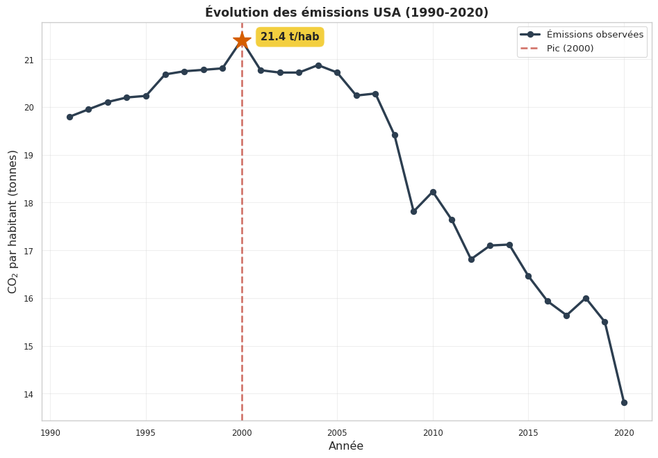

**Modèle ARDL(1,1)**

$$\ln(\mathrm{CO}_2)_t = \rho \ln(\mathrm{CO}_2)_{t-1} + \beta_0 \ln(\text{PIB})_t + \beta_1 \ln(\text{PIB})_{t-1} + \varepsilon_t$$

**Résultats clés**

[output not shown]

**⚠️ Inertie structurelle**

$\rho \approx 1$ → Chocs **quasi-permanents**

Demi-vie : **Non calculable**

## 🔮 Projection 2025 et validation hors-échantillon

- Projection
- Validation

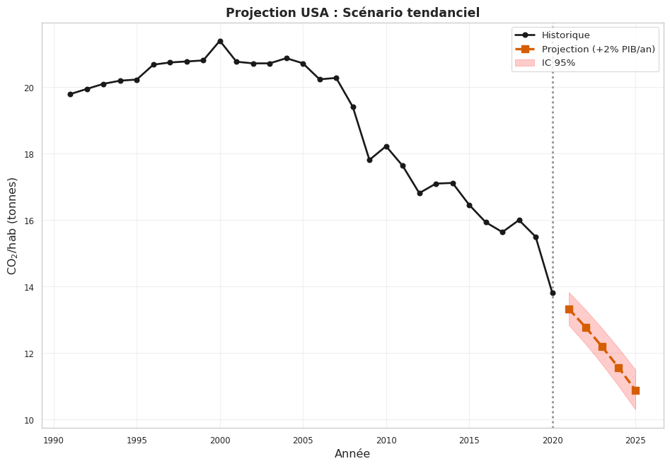

**Écart avec l’Accord de Paris**

[output not shown]

→ Gap de **29 points** : trajectoire insuffisante.

**Performance hors-échantillon (2016-2020)**

| Modèle | RMSE | vs ARDL |
| --- | --- | --- |
| **ARDL Quadratique** | **0.047** | — |
| ARIMA(1,1,1) | 0.050 | +6% |
| Marche aléatoire | 0.052 | +11% |

**✅ ARDL bat tous les benchmarks**

Sur données **non vues** (2016-2020), l’ARDL offre l’erreur la plus faible.

→ La capacité prédictive du modèle est validée.

# Conclusion

## 🧩 Confrontation et implications

Les deux approches convergent-elles ? Que faire ?

## ⚖️ Confrontation des deux approches

### ✅ Convergence

- Modèle **quadratique** suffit
- Courbe en **N rejetée** ($\beta_3 \approx 0$)
- EKC classique **validée**
- Découplage **réel** (pays riches)

### ⚠️ Divergence

- **Transversal** : Découplage *possible*
- **Temporel** : Découplage *lent* ($\rho \approx 1$)
- Élasticité CT faible : $-0.12$
- Transition **30+ ans**

**Synthèse**

L’EKC existe mais elle est :

- **Conditionnelle** (pas automatique)
- **Hétérogène** (facteur 9 entre pays)
- **Lente** (inertie structurelle)

→ Le marché seul **ne sauvera pas** le climat

## 💡 Implications pour l’action climatique

**1. 🚫 Limites du Marché**

L’EKC n’est **pas automatique** (ex: Suède vs Qatar). *Instruments requis* : taxe carbone, normes, R&D.

**2. ⏳ Inertie Structurelle**

Demi-vie du capital ~5+ ans.  
*Lock-in* : Les choix d’aujourd’hui nous engagent pour **30 ans**.

**3. 📉 Écart Net Zero**

Trajectoire USA : **-21%** (projeté) vs **-50%** (Paris).  
Besoin de **rupture** politique, pas de continuité.

**4. 🚀 Opportunité du Sud**

*Tunneling* : Éviter le pic pollueur des pays riches.  
Transferts technologiques et financiers **essentiels**.

## 📝 Messages clés

**Trois enseignements clés**

1. **L’EKC existe** → mais elle est **conditionnelle**, pas automatique.
2. **L’inertie est réelle** → $\rho \approx 1$ : chaque année de retard se paie sur 30 ans.
3. **Les politiques sont décisives** → La Suède (4t) prouve que la décarbonation est possible.

**« Le marché ne sauvera pas le climat.**

**Seules des politiques publiques ciblées, durables et ambitieuses le feront. »**

## Merci pour votre attention !

## Questions & Réponses ?

- ❓ Méthodologie
- ❓ Données
- ❓ Projections
- 📞 Contact

**“Pourquoi écarter le cubique ?”** Triple raison :

1. $\beta_3$ non significatif ($p=0.995$)
2. AIC moins bon (+2 points)
3. RMSE en validation croisée supérieur.

→ **Parcimonie** validée.

**“Biais pollution haven ?”** Reconnu. Nous utilisons les émissions **territoriales** (production). Les émissions basées sur la **consommation** (empreinte carbone) montreraient un découplage plus lent, mais la tendance reste la même pour les USA depuis 2005.

**“Et après 2025 ?”** L’inertie ($\rho \approx 1$) rend les intervalles de confiance explosifs après 5 ans. Pour aller plus loin (2030-2050), il faudrait un modèle structurel avec des scénarios technologiques, pas juste économétrique.

**Pour aller plus loin :**

- 💻 Code & Données : [acquisition-donnees-owid](https://github.com/Morph-aion/kuznets_environmental_curve/blob/main/notebooks/01-acquisition-donnees-owid.ipynb)
- 📄 Rapport complet disponible (51 pages) : [rapport-anglais](https://github.com/Morph-aion/kuznets_environmental_curve/blob/main/output/_book/en/The-Environmental-Kuznets-Curve-for-%24CO_2%24.pdf)

# Annexes

## A1. Schéma global de la démarche statistique

[figure not shown]

*Figure A4 : Résumé de la démarche (Source : Auteur)*

## A2. Statistiques descriptives

[output not shown]

**Source** : Our World in Data (2020) | **Échantillon** : 159 pays

## A3. Résultats complets OLS (transversal)

| Variable | Linéaire | Quadratique | Cubique |
| --- | --- | --- | --- |
| $\ln(\text{PIB})$ | 1.100*** | 1.070*** | 1.070*** |
|  | (0.043) | (0.043) | (0.083) |
| $[\ln(\text{PIB})]^2$ | — | -0.083*** | -0.083** |
|  |  | (0.032) | (0.040) |
| $[\ln(\text{PIB})]^3$ | — | — | -0.0002 |
|  |  |  | (0.027) |
| $R^2$ adj. | 0.836 | **0.842** | 0.841 |
| AIC | 279.6 | **274.0** | 276.0 |

*Erreurs-types HC3. *p<0.1, **p<0.05, ***p<0.01*

## A4. Résultats complets ARDL (temporel)

| Variable | AR(1) | ARDL lin. | ARDL quad. |
| --- | --- | --- | --- |
| $\ln(\mathrm{CO}_2)_{t-1}$ | 1.052*** | 1.003*** | 1.097*** |
|  | (0.062) | (0.078) | (0.053) |
| $\ln(\text{PIB})_t$ | — | -0.064* | -0.122* |
|  |  | (0.033) | (0.063) |
| $[\ln(\text{PIB})_t]^2$ | — | — | -0.422 |
|  |  |  | (0.398) |
| $R^2$ | 0.935 | 0.938 | 0.939 |
| AIC | **-121.5** | -120.8 | -119.3 |

*Erreurs-types Newey-West (3 lags). *p<0.1, **p<0.05, ***p<0.01*